# Self-Driving Car Engineer Nanodegree

## Project: Build a Traffic Sign Recognition Classifier

In this notebook, a template is provided for you to implement your functionality in stages, which is required to successfully complete this project. If additional code is required that cannot be included in the notebook, be sure that the Python code is successfully imported and included in your submission if necessary.

In addition to implementing code, there is a writeup to complete. The writeup should be completed in a separate file, which can be either a markdown file or a pdf document. There is a [write up template](https://github.com/udacity/CarND-Traffic-Sign-Classifier-Project/blob/master/writeup_template.md) that can be used to guide the writing process. Completing the code template and writeup template will cover all of the [rubric points](https://review.udacity.com/#!/rubrics/481/view) for this project.

The [rubric](https://review.udacity.com/#!/rubrics/481/view) contains "Stand Out Suggestions" for enhancing the project beyond the minimum requirements. The stand out suggestions are optional. If you decide to pursue the "stand out suggestions", you can include the code in this Ipython notebook and also discuss the results in the writeup file.

> **Note:** Code and Markdown cells can be executed using the **Shift + Enter** keyboard shortcut. In addition, Markdown cells can be edited by typically double-clicking the cell to enter edit mode.

### Step 0.5

- install additional dependencies
- import required modules
- print TF version

```python
!pip install numpy
!pip install pandas
!pip install matplotlib
```

```python
import pickle
import pandas as pd
import numpy as np
import matplotlib.pyplot as plt
import tensorflow as tf
```

```python
# Visualizations will be shown in the notebook.
%matplotlib inline
```

```python
print( tf.version.VERSION )
```

```
2.2.0
```

## Step 0: Load The Data

```python
# Load pickled data

# DONE: Fill this in based on where you saved the training and testing data

BASE_PATH = '../data/'

def load_pickle( file_path ) :
    with open( file_path, mode='rb') as f:
        return pickle.load(f)
try :
    train = load_pickle( BASE_PATH + 'train.p' )
    valid = load_pickle( BASE_PATH + 'valid.p' )
    test  = load_pickle( BASE_PATH + 'test.p'  )

    sign_names_pd = pd.read_csv('./signnames.csv')
    print( 'done' )

except :
    print( 'load failed' )
```

```
done
```

## Step 1: Dataset Summary & Exploration

The pickled data is a dictionary with 4 key/value pairs:

- `'features'` is a 4D array containing raw pixel data of the traffic sign images, (num examples, width, height, channels).
- `'labels'` is a 1D array containing the label/class id of the traffic sign. The file `signnames.csv` contains id -> name mappings for each id.
- `'sizes'` is a list containing tuples, (width, height) representing the original width and height the image.
- `'coords'` is a list containing tuples, (x1, y1, x2, y2) representing coordinates of a bounding box around the sign in the image. **THESE COORDINATES ASSUME THE ORIGINAL IMAGE. THE PICKLED DATA CONTAINS RESIZED VERSIONS (32 by 32) OF THESE IMAGES**

Complete the basic data summary below. Use python, numpy and/or pandas methods to calculate the data summary rather than hard coding the results. For example, the [pandas shape method](http://pandas.pydata.org/pandas-docs/stable/generated/pandas.DataFrame.shape.html) might be useful for calculating some of the summary results.

### Provide a Basic Summary of the Data Set Using Python, Numpy and/or Pandas

```python
# DONE: Number of training examples
n_train = train['features'].shape[0]

# DONE: Number of validation examples
n_validation =  valid['features'].shape[0]

# DONE: Number of testing examples.
n_test = test['features'].shape[0]

# DONE: What's the shape of an traffic sign image?
image_shape = test['features'][-1].shape

# DONE: How many unique classes/labels there are in the dataset.
n_classes = sign_names_pd.shape[0]

print('Number of training examples   = {:7d}'.format( n_train ) )
print('Number of validating examples = {:7d}'.format( n_validation ) )
print('Number of testing examples    = {:7d}'.format(n_test) )
print('Image data shape (WxHxC)      = {:2d}x{:2d}x{:d}'.format( image_shape[0],image_shape[1],image_shape[2] ) )
print('Number of classes             = {:7d}'.format(n_classes) )
```

```
Number of training examples   =   34799
Number of validating examples =    4410
Number of testing examples    =   12630
Image data shape (WxHxC)      = 32x32x3
Number of classes             =      43
```

### Include an exploratory visualization of the dataset

Visualize the German Traffic Signs Dataset using the pickled file(s). This is open ended, suggestions include: plotting traffic sign images, plotting the count of each sign, etc.

The [Matplotlib](http://matplotlib.org/) [examples](http://matplotlib.org/examples/index.html) and [gallery](http://matplotlib.org/gallery.html) pages are a great resource for doing visualizations in Python.

**NOTE:** It's recommended you start with something simple first. If you wish to do more, come back to it after you've completed the rest of the sections. It can be interesting to look at the distribution of classes in the training, validation and test set. Is the distribution the same? Are there more examples of some classes than others?

```python
### Data exploration visualization code goes here.
### Feel free to use as many code cells as needed.

def draw_samples( ds ) :

    cols=6
    rows=2
    plt.rcParams["figure.figsize"] = (10,10)

    samples_idx = np.random.randint(low=0, high=ds['features'].shape[0], size=cols*rows )

    fig = plt.figure()

    ax=[None]*len(samples_idx)

    for i in range( 0, len(samples_idx) ):
        ax[i] = fig.add_subplot(rows,cols,i+1)

        str_id = str( samples_idx[i] )
        str_label = sign_names_pd.iloc[ train['labels'][samples_idx[i]] ][1]
        ax[i].set_title( str_id +'\n' + str_label.replace(' ', '\n') )

        ax[i].imshow(ds['features'][samples_idx[i]])

    plt.show()

def count_classes ( labels, sign_names ) :

    x = []
    y = []
    l = []
    c = []

    for i in  range( sign_names.shape[0] ) :
        l.append(  str(i)+'. ' + sign_names.iloc[i][1] )
        x.append( sign_names.iloc[i][0] )
        y.append( 0 )

    for i in labels :
        y[i] = y[i]+1

    treshhold = labels.shape[0] //  sign_names.shape[0]
    for v in y:
        if v < treshhold // 2 :
            c.append((1,0,0))
        elif v >= treshhold // 2 and v < treshhold :
            c.append((1,0,0.95))
        elif v >= treshhold and v < 3*treshhold//2 :
            c.append((1,0.95,0))
        else:
            c.append((0,0.7,0))

    #y = np.array( np.array(y) / labels.shape[0] ).tolist()

    return x,y,l,c


def draw_classes( ds, sign_names ) :
    x,y,l,c = count_classes( ds['labels'], sign_names )
    plt.ylabel( 'Numbers of samples' )
    plt.xlabel( 'Class name' )
    plt.bar(x,y,color=c)
    # Specify a rotation for the tick labels in degrees.
    plt.xticks(x, l, rotation='87')
    # Pad margins so that markers don't get clipped by the axes
    plt.margins(0.2)
    # Tweak spacing to prevent clipping of tick-labels
    plt.subplots_adjust(bottom=0.15)
    plt.show()

    #for ix in x :
    #    if y[ix] < 500 :
    #        print( l[ix], y[ix])
```

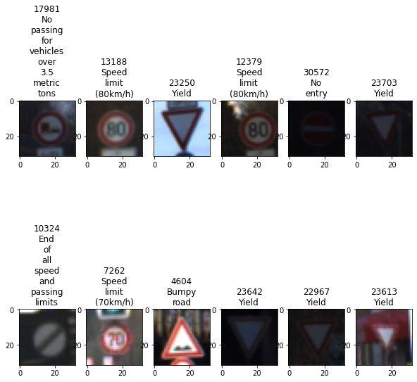

```python
draw_samples( train )
```

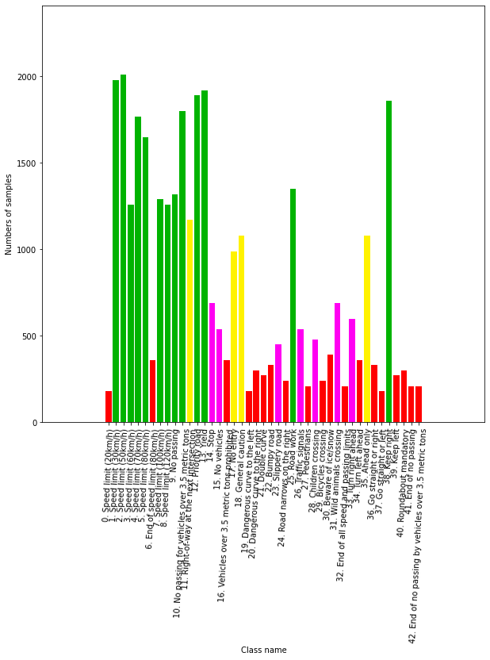

```python
draw_classes( train, sign_names_pd )
if False:
    draw_classes( valid, sign_names_pd )
    draw_classes( test, sign_names_pd )
```

## Step 2: Design and Test a Model Architecture

Design and implement a deep learning model that learns to recognize traffic signs. Train and test your model on the [German Traffic Sign Dataset](http://benchmark.ini.rub.de/?section=gtsrb&subsection=dataset).

The LeNet-5 implementation shown in the classroom at the end of the CNN lesson is a solid starting point. You'll have to change the number of classes and possibly the preprocessing, but aside from that it's plug and play!

With the LeNet-5 solution from the lecture, you should expect a validation set accuracy of about 0.89. To meet specifications, the validation set accuracy will need to be at least 0.93. It is possible to get an even higher accuracy, but 0.93 is the minimum for a successful project submission.

There are various aspects to consider when thinking about this problem:

- Neural network architecture (is the network over or underfitting?)
- Play around preprocessing techniques (normalization, rgb to grayscale, etc)
- Number of examples per label (some have more than others).
- Generate fake data.

Here is an example of a [published baseline model on this problem](http://yann.lecun.com/exdb/publis/pdf/sermanet-ijcnn-11.pdf). It's not required to be familiar with the approach used in the paper but, it's good practice to try to read papers like these.

```python
BATCH_SIZE = 196

AUTOTUNE = tf.data.experimental.AUTOTUNE
```

```python
base_model_results=[]
modified_model_results=[]
```

### Pre-process the Data Set (normalization, grayscale, etc.)

Minimally, the image data should be normalized so that the data has mean zero and equal variance. For image data, `(pixel - 128)/ 128` is a quick way to approximately normalize the data and can be used in this project.

Other pre-processing steps are optional. You can try different techniques to see if it improves performance.

Use the code cell (or multiple code cells, if necessary) to implement the first step of your project.

```python
with tf.device('/device:GPU:1') :
    x = np.array( [[[ 1, 0,   0],
                    [ 4, 5, 127]],
        [[128,  8,   9],
         [ 10, 11, 255] ]], dtype='uint8' )

    y = tf.image.convert_image_dtype(x, dtype=tf.float32)

    print( y )


    xf = np.array( [[[ 1.0, 0.0,   0.0],
                [ 4.0, 5.0, 127.0]],
    [[128.0,  8.0,   9.0],
     [ 10.0, 11.0, 255.0] ]] )

    yf = tf.image.convert_image_dtype(xf, dtype=tf.float32)

    print( yf )
```

```
tf.Tensor(
[[[0.00392157 0.         0.        ]
  [0.01568628 0.01960784 0.49803925]]

 [[0.5019608  0.03137255 0.03529412]
  [0.03921569 0.04313726 1.        ]]], shape=(2, 2, 3), dtype=float32)
WARNING:tensorflow:The operation `tf.image.convert_image_dtype` will not automatically renormalize input data since input and output dtypes are both floating point formats.
tf.Tensor(
[[[  1.   0.   0.]
  [  4.   5. 127.]]

 [[128.   8.   9.]
  [ 10.  11. 255.]]], shape=(2, 2, 3), dtype=float32)
```

[figure not shown]

```python
### Preprocess the data here. It is required to normalize the data. Other preprocessing steps could include
### converting to grayscale, etc.
### Feel free to use as many code cells as needed.

plt.rcParams["figure.figsize"] = (7,7)

ids = [24189,  11415, 28573, 7879, 19745 ]

fig = plt.figure()

rows = len(ids)
cols = 4

ax = [None] * ( rows * cols)

i=0

for id in ids :
    image = train['features'][id]

    #image = tf.image.convert_image_dtype( image, dtype=tf.float32)

    ax[i] = fig.add_subplot(rows,cols,1+i)
    ax[i].set_title( 'source' )
    #ax[i].imshow( (image*255).numpy().astype(np.uint8) )
    ax[i].imshow( image )
    i=i+1

    imageS = tf.image.per_image_standardization( image )
    ax[i] = fig.add_subplot(rows,cols,1+i)
    ax[i].set_title( 'std.' )
    ax[i].imshow( imageS )
    i=i+1

    imageG = tf.image.rgb_to_grayscale( image )
    ax[i] = fig.add_subplot(rows,cols,1+i)
    ax[i].set_title( 'graed' )
    ax[i].imshow( imageG, cmap='gray' )
    i=i+1

    imageA = tf.image.adjust_gamma( image )
    ax[i] = fig.add_subplot(rows,cols,1+i)
    ax[i].set_title( 'gammacor.' )
    ax[i].imshow( imageA )
    i=i+1

plt.show()

# resize

# rescaling (normalization)

#    tf.keras.layers.experimental.preprocessing.Rescaling( scale = 1./255 )
```

```python
def prepare_dataset( in_data, useRGB, preprocessing, batch_size = BATCH_SIZE ) :
    x = in_data['features']
    #print( 'L03: ', x[7][6][5][1] )
    x = tf.image.convert_image_dtype( x, dtype=tf.float32 )
    #print( 'L05: ', x[7][6][5][1] )

    if preprocessing == True :
        x = tf.image.per_image_standardization( x )

    if useRGB == False :
        x = tf.image.rgb_to_grayscale( x )

    y = in_data['labels']

    features_dataset = tf.data.Dataset.from_tensor_slices( x )
    labels_dataset = tf.data.Dataset.from_tensor_slices( y )
    ds = tf.data.Dataset.zip((features_dataset, labels_dataset))
    ds = ds.batch( batch_size )
    ds = ds.shuffle( x.shape[0] )
    ds = ds.prefetch(buffer_size=AUTOTUNE)

    return ds

### Define your architecture here.
### Feel free to use as many code cells as needed.
```

```python
def plot_history( history ):
    acc = history.history['sparse_categorical_accuracy']
    val_acc = history.history['val_sparse_categorical_accuracy']

    loss = history.history['loss']
    val_loss = history.history['val_loss']

    epochs_range = range( len( history.history['loss'] ) )

    plt.figure(figsize=(8, 8))
    plt.subplot(1, 2, 1)
    plt.plot(epochs_range, acc, label='Training Accuracy')
    plt.plot(epochs_range, val_acc, label='Validation Accuracy')
    plt.legend(loc='lower right')
    plt.title('Training and Validation Accuracy')

    plt.subplot(1, 2, 2)
    plt.plot(epochs_range, loss, label='Training Loss')
    plt.plot(epochs_range, val_loss, label='Validation Loss')
    plt.legend(loc='upper right')
    plt.title('Training and Validation Loss')
    #plt.xscale('log')
    plt.show()
```

### Model Architecture

```python
def get_LeNet5( useRGB, preprocessing ) :

    input_shape = ( image_shape[0],image_shape[1], image_shape[2] if useRGB else 1 )

    input_layer = tf.keras.layers.InputLayer( input_shape=input_shape )
    preprocessing_layer = tf.keras.layers.experimental.preprocessing.Rescaling(scale = 1./255, input_shape=input_shape )

    lenet5 =  tf.keras.Sequential([
                input_layer if preprocessing == False else preprocessing_layer,
                tf.keras.layers.Conv2D( filters=6, kernel_size=(5,5), strides=1, padding='valid', activation='relu' ),
                tf.keras.layers.MaxPool2D( pool_size=(2, 2), strides=2 ),
                tf.keras.layers.Conv2D(filters=16, kernel_size=(5,5), padding='valid', activation='relu'),
                tf.keras.layers.MaxPool2D( pool_size=(2, 2), strides=2 ),
                tf.keras.layers.Flatten(),
                tf.keras.layers.Dense(n_classes*4, activation='relu'),
                tf.keras.layers.Dense(n_classes*2, activation='relu'),
                tf.keras.layers.Dense(n_classes )
            ], name = 'LeNet5.body' )

    return lenet5
```

```python
def get_modified_LeNet5( useRGB, preprocessing ) :

    input_shape = ( image_shape[0],image_shape[1], image_shape[2] if useRGB else 1 )

    input_layer = tf.keras.layers.InputLayer( input_shape=input_shape )
    preprocessing_layer = tf.keras.layers.experimental.preprocessing.Rescaling(scale = 1./255, input_shape=input_shape )

    model = tf.keras.Sequential([

            input_layer if preprocessing == False else preprocessing_layer,

            tf.keras.layers.Conv2D( filters=6, kernel_size=(3,3), strides=1, padding='valid', activation='relu' ),
            tf.keras.layers.MaxPool2D( pool_size=(2, 2), strides=1 ),

            tf.keras.layers.Conv2D(filters=18, kernel_size=(3,3), strides=1, padding='valid', activation='relu'),
            tf.keras.layers.MaxPool2D( pool_size=(2, 2), strides=1 ),

            tf.keras.layers.Conv2D(filters=48, kernel_size=(2,2), strides=1, padding='valid', activation='relu'),
            tf.keras.layers.MaxPool2D( pool_size=(2, 2), strides=2 ),

            tf.keras.layers.Conv2D(filters=96, kernel_size=(2,2), strides=1, padding='valid', activation='relu'),
            tf.keras.layers.MaxPool2D( pool_size=(2, 2), strides=2 ),

            tf.keras.layers.Flatten(),
            tf.keras.layers.Dropout(0.3),
            tf.keras.layers.Dense( 180, activation='relu' ),

            tf.keras.layers.Dropout(0.3),
            tf.keras.layers.Dense( 100, activation='relu' ),

            tf.keras.layers.Dropout(0.2),
            tf.keras.layers.Dense(n_classes )
        ], name = 'Modified.LeNet5'
    )

    return model
```

### Train, Validate and Test the Model

A validation set can be used to assess how well the model is performing. A low accuracy on the training and validation sets imply underfitting. A high accuracy on the training set but low accuracy on the validation set implies overfitting.

```python
### Train your model here.
### Calculate and report the accuracy on the training and validation set.
### Once a final model architecture is selected,
### the accuracy on the test set should be calculated and reported as well.
### Feel free to use as many code cells as needed.

def create_and_fit(    number_of_epochs,
                       useRGB,
                       preprocessing,
                       fit_verbosity,
                       test_base_model=False
                  ) :
    train_ds = prepare_dataset( train, useRGB=useRGB, preprocessing = preprocessing )
    val_ds   = prepare_dataset( valid, useRGB=useRGB, preprocessing = preprocessing )

    model = None

    if test_base_model :
        model = get_LeNet5( useRGB=useRGB, preprocessing = preprocessing )
    else :
        model = get_modified_LeNet5(  useRGB=useRGB, preprocessing = preprocessing  )

    model.compile( optimizer = 'adam',
                  loss = tf.keras.losses.SparseCategoricalCrossentropy( from_logits=True ),
                  metrics=[ tf.keras.metrics.SparseCategoricalAccuracy() ] )

    history = model.fit(
      train_ds,
      validation_data=val_ds,
      epochs = number_of_epochs,
      verbose = fit_verbosity # 2
    )

    return history, model
```

```python
def plot_test( data, spec ) :
    x = range(4)
    plt.figure(figsize=(8, 8))
    plt.plot(x, np.array(data).T[0], label='Validation Loss')
    plt.plot(x, np.array(data).T[1], label='Validation Accuracy')
    plt.xticks(x, ['RGB+Preproc','Gray+Preproc','RGB+NoPreproc','Gray+NoPreproc'], rotation='87')
    plt.title( spec )
    plt.legend(loc='lower right')
    plt.show()
```

```python
def try_base_with_params( useRGB, preprocessing ) :
    print( useRGB, preprocessing )
    history, model = create_and_fit( number_of_epochs=20, useRGB=useRGB, preprocessing=preprocessing, fit_verbosity=0, test_base_model=True )
    # plot_history( history )
    return model.evaluate( prepare_dataset(test, useRGB=useRGB, preprocessing=preprocessing) )

# do it only onse
if len(base_model_results)==0 :
    with tf.device('/device:GPU:1') :
        base_model_results.append( try_base_with_params( useRGB=True,  preprocessing=True  ) )
        base_model_results.append( try_base_with_params( useRGB=False, preprocessing=True  ) )
        base_model_results.append( try_base_with_params( useRGB=True,  preprocessing=False ) )
        base_model_results.append( try_base_with_params( useRGB=False, preprocessing=False ) )
```

[output not shown]

```
[3.4642913341522217, 0.059382423758506775]
[3.0986886024475098, 0.13238321244716644]
[0.6153956651687622, 0.8476642966270447]
[0.7782442569732666, 0.7780680656433105]
```

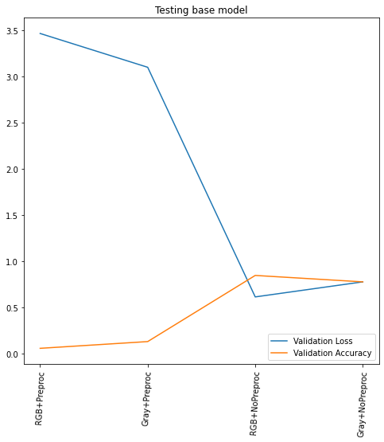

```python
if len(base_model_results)==4 :
    for r in base_model_results :
        print( r )
    plot_test( base_model_results, 'Testing base model')
```

```python
def try_with_params( useRGB, preprocessing ) :
    print( useRGB, preprocessing )
    history, model = create_and_fit( number_of_epochs=20, useRGB=useRGB, preprocessing=preprocessing, fit_verbosity=0 )
    # plot_history( history )
    return model.evaluate( prepare_dataset(test, useRGB=useRGB, preprocessing=preprocessing) )

# collect this only once
if len(modified_model_results) == 0:
    with tf.device('/device:GPU:1') :
        modified_model_results.append( try_with_params( useRGB=True,  preprocessing=True  ) )
        modified_model_results.append( try_with_params( useRGB=False, preprocessing=True  ) )
        modified_model_results.append( try_with_params( useRGB=True,  preprocessing=False ) )
        modified_model_results.append( try_with_params( useRGB=False, preprocessing=False ) )
```

[output not shown]

```
[3.4531965255737305, 0.059382423758506775]
[3.4657764434814453, 0.059382423758506775]
[0.2928082346916199, 0.9078384637832642]
[0.6355993151664734, 0.8012668490409851]
```

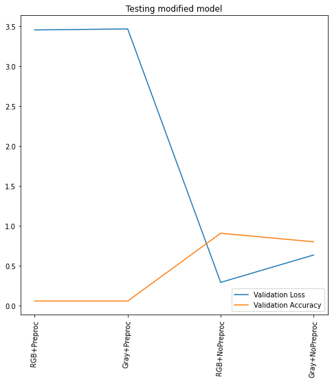

```python
if len(modified_model_results) == 4 :
    for ir in modified_model_results:
        print( ir )
    plot_test( modified_model_results, 'Testing modified model')
```

```python
with tf.device('/device:GPU:1') :
    history, model = create_and_fit( number_of_epochs=60,
                                    useRGB=True,
                                    preprocessing=False,
                                    fit_verbosity=2
                                   )
```

```
178/178 - 1s - loss: 3.7102 - sparse_categorical_accuracy: 0.0222 - val_loss: 3.6026 - val_sparse_categorical_accuracy: 0.0544
178/178 - 1s - loss: 3.5868 - sparse_categorical_accuracy: 0.0449 - val_loss: 3.5621 - val_sparse_categorical_accuracy: 0.0569
178/178 - 1s - loss: 3.5625 - sparse_categorical_accuracy: 0.0462 - val_loss: 3.5469 - val_sparse_categorical_accuracy: 0.0544
178/178 - 1s - loss: 3.4961 - sparse_categorical_accuracy: 0.0631 - val_loss: 3.4849 - val_sparse_categorical_accuracy: 0.0889
178/178 - 1s - loss: 3.4117 - sparse_categorical_accuracy: 0.0776 - val_loss: 3.1981 - val_sparse_categorical_accuracy: 0.1617
178/178 - 1s - loss: 3.0873 - sparse_categorical_accuracy: 0.1713 - val_loss: 2.8121 - val_sparse_categorical_accuracy: 0.2875
178/178 - 1s - loss: 2.7064 - sparse_categorical_accuracy: 0.2875 - val_loss: 2.3731 - val_sparse_categorical_accuracy: 0.3363
178/178 - 1s - loss: 2.3360 - sparse_categorical_accuracy: 0.3440 - val_loss: 2.0686 - val_sparse_categorical_accuracy: 0.4000
178/178 - 1s - loss: 2.0202 - sparse_categorical_accuracy: 0.4034 - val_loss: 1.7806 - val_sparse_categorical_accuracy: 0.4385
178/178 - 1s - loss: 1.8199 - sparse_categorical_accuracy: 0.4285 - val_loss: 1.6523 - val_sparse_categorical_accuracy: 0.4841
178/178 - 1s - loss: 1.6302 - sparse_categorical_accuracy: 0.4888 - val_loss: 1.4313 - val_sparse_categorical_accuracy: 0.5721
178/178 - 1s - loss: 1.4730 - sparse_categorical_accuracy: 0.5319 - val_loss: 1.2788 - val_sparse_categorical_accuracy: 0.5644
178/178 - 1s - loss: 1.2579 - sparse_categorical_accuracy: 0.5968 - val_loss: 1.0113 - val_sparse_categorical_accuracy: 0.6526
178/178 - 1s - loss: 1.1498 - sparse_categorical_accuracy: 0.6188 - val_loss: 0.9071 - val_sparse_categorical_accuracy: 0.7184
178/178 - 1s - loss: 1.0388 - sparse_categorical_accuracy: 0.6503 - val_loss: 0.7232 - val_sparse_categorical_accuracy: 0.7776
178/178 - 1s - loss: 0.9333 - sparse_categorical_accuracy: 0.6884 - val_loss: 0.7018 - val_sparse_categorical_accuracy: 0.7630
178/178 - 1s - loss: 0.8293 - sparse_categorical_accuracy: 0.7175 - val_loss: 0.6395 - val_sparse_categorical_accuracy: 0.8095
178/178 - 1s - loss: 0.7347 - sparse_categorical_accuracy: 0.7477 - val_loss: 0.5629 - val_sparse_categorical_accuracy: 0.8338
178/178 - 1s - loss: 0.6876 - sparse_categorical_accuracy: 0.7607 - val_loss: 0.4676 - val_sparse_categorical_accuracy: 0.8531
178/178 - 1s - loss: 0.6176 - sparse_categorical_accuracy: 0.7834 - val_loss: 0.4866 - val_sparse_categorical_accuracy: 0.8308
178/178 - 1s - loss: 0.5734 - sparse_categorical_accuracy: 0.8011 - val_loss: 0.3824 - val_sparse_categorical_accuracy: 0.8764
178/178 - 1s - loss: 0.5343 - sparse_categorical_accuracy: 0.8129 - val_loss: 0.3741 - val_sparse_categorical_accuracy: 0.8857
178/178 - 1s - loss: 0.5141 - sparse_categorical_accuracy: 0.8247 - val_loss: 0.3270 - val_sparse_categorical_accuracy: 0.8995
178/178 - 1s - loss: 0.4762 - sparse_categorical_accuracy: 0.8336 - val_loss: 0.3311 - val_sparse_categorical_accuracy: 0.8991
178/178 - 1s - loss: 0.4197 - sparse_categorical_accuracy: 0.8589 - val_loss: 0.3167 - val_sparse_categorical_accuracy: 0.8918
178/178 - 1s - loss: 0.3811 - sparse_categorical_accuracy: 0.8713 - val_loss: 0.3099 - val_sparse_categorical_accuracy: 0.8934
178/178 - 1s - loss: 0.3624 - sparse_categorical_accuracy: 0.8797 - val_loss: 0.2701 - val_sparse_categorical_accuracy: 0.9213
178/178 - 1s - loss: 0.3311 - sparse_categorical_accuracy: 0.8895 - val_loss: 0.2440 - val_sparse_categorical_accuracy: 0.9206
178/178 - 1s - loss: 0.2921 - sparse_categorical_accuracy: 0.9053 - val_loss: 0.1990 - val_sparse_categorical_accuracy: 0.9413
178/178 - 1s - loss: 0.2878 - sparse_categorical_accuracy: 0.9045 - val_loss: 0.2054 - val_sparse_categorical_accuracy: 0.9379
178/178 - 1s - loss: 0.2788 - sparse_categorical_accuracy: 0.9067 - val_loss: 0.1701 - val_sparse_categorical_accuracy: 0.9503
178/178 - 1s - loss: 0.2365 - sparse_categorical_accuracy: 0.9243 - val_loss: 0.1637 - val_sparse_categorical_accuracy: 0.9542
178/178 - 1s - loss: 0.2551 - sparse_categorical_accuracy: 0.9163 - val_loss: 0.1752 - val_sparse_categorical_accuracy: 0.9456
178/178 - 1s - loss: 0.2178 - sparse_categorical_accuracy: 0.9280 - val_loss: 0.1454 - val_sparse_categorical_accuracy: 0.9594
178/178 - 1s - loss: 0.2022 - sparse_categorical_accuracy: 0.9345 - val_loss: 0.1323 - val_sparse_categorical_accuracy: 0.9590
178/178 - 1s - loss: 0.1882 - sparse_categorical_accuracy: 0.9395 - val_loss: 0.1305 - val_sparse_categorical_accuracy: 0.9642
178/178 - 1s - loss: 0.1711 - sparse_categorical_accuracy: 0.9442 - val_loss: 0.1228 - val_sparse_categorical_accuracy: 0.9646
178/178 - 1s - loss: 0.1590 - sparse_categorical_accuracy: 0.9492 - val_loss: 0.1427 - val_sparse_categorical_accuracy: 0.9590
178/178 - 1s - loss: 0.1571 - sparse_categorical_accuracy: 0.9490 - val_loss: 0.1190 - val_sparse_categorical_accuracy: 0.9671
178/178 - 1s - loss: 0.1393 - sparse_categorical_accuracy: 0.9546 - val_loss: 0.1428 - val_sparse_categorical_accuracy: 0.9590
```

[output cut: 20 more lines]

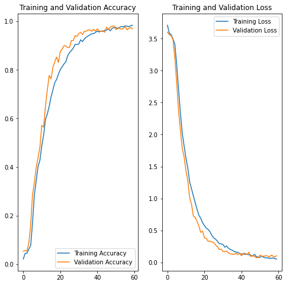

```python
plot_history( history )
```

```python
with tf.device('/device:GPU:1') :
    model.evaluate( prepare_dataset(test, useRGB=True, preprocessing=False) )
```

[output not shown]

```python
model.summary()
```

```
Model: "Modified.LeNet5"
_________________________________________________________________
Layer (type)                 Output Shape              Param #
=================================================================
conv2d_92 (Conv2D)           (None, 30, 30, 6)         168
_________________________________________________________________
max_pooling2d_92 (MaxPooling (None, 29, 29, 6)         0
_________________________________________________________________
conv2d_93 (Conv2D)           (None, 27, 27, 18)        990
_________________________________________________________________
max_pooling2d_93 (MaxPooling (None, 26, 26, 18)        0
_________________________________________________________________
conv2d_94 (Conv2D)           (None, 25, 25, 48)        3504
_________________________________________________________________
max_pooling2d_94 (MaxPooling (None, 12, 12, 48)        0
_________________________________________________________________
conv2d_95 (Conv2D)           (None, 11, 11, 96)        18528
_________________________________________________________________
max_pooling2d_95 (MaxPooling (None, 5, 5, 96)          0
_________________________________________________________________
flatten_29 (Flatten)         (None, 2400)              0
_________________________________________________________________
dropout_51 (Dropout)         (None, 2400)              0
_________________________________________________________________
dense_87 (Dense)             (None, 180)               432180
_________________________________________________________________
dropout_52 (Dropout)         (None, 180)               0
_________________________________________________________________
dense_88 (Dense)             (None, 100)               18100
_________________________________________________________________
dropout_53 (Dropout)         (None, 100)               0
_________________________________________________________________
dense_89 (Dense)             (None, 43)                4343
=================================================================
Total params: 477,813
Trainable params: 477,813
Non-trainable params: 0
_________________________________________________________________
```

```python
#model.save('./dev/null')
```

## Step 3: Test a Model on New Images

To give yourself more insight into how your model is working, download at least five pictures of German traffic signs from the web and use your model to predict the traffic sign type.

You may find `signnames.csv` useful as it contains mappings from the class id (integer) to the actual sign name.

### Load and Output the Images

```
Speed limit (30km/h)
```

```
Road work
```

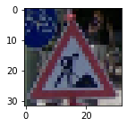

```
Ahead only
```

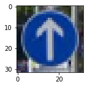

```
Priority road
```

[figure not shown]

```
Yield
```

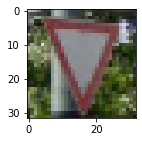

```
Bicycles crossing
```

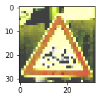

```
Bicycles crossing
```

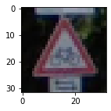

```
Stop
```

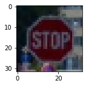

```python
### https://www.google.com/maps/@52.5030512,13.3494911,3a,15.5y,251.44h,87.25t/data=!3m6!1e1!3m4!1s14UBnG2MfoFVUCqpK1PA1Q!2e0!7i13312!8i6656
### https://www.google.de/maps/@48.1124572,11.5545795,3a,16.9y,320.76h,91.89t/data=!3m6!1e1!3m4!1sj5Kcd3SGxWlCU0Hq9cVjDA!2e0!7i13312!8i6656!5m1!1e3

plt.rcParams["figure.figsize"] = (2,2)

### Load the images and plot them here.
### Feel free to use as many code cells as needed.
new_signs=['ahead_only.jpg',
           'priority_road.jpg',
           'stop.jpg',
           'road_work.jpg',
           'yield.jpg',
           '30.jpg',
           'bicycles_crossing.jpg',
           'bicycles_crossing2.jpg'
          ]

new_raw_ds={
    'features' : np.zeros( ( len(new_signs),32,32,3), dtype=np.uint8 ),
    'labels':  [ 35,12,14,25,13,1,29,29 ]
}

with tf.device('/device:GPU:1') :
    for i in range( len( new_signs ) ):

        image_path = './from_web/' + new_signs[i]

        im = tf.keras.preprocessing.image.load_img( image_path );
        im = tf.keras.preprocessing.image.img_to_array( im )
        im = tf.image.resize( im, (image_shape[0],image_shape[1]) )
        new_raw_ds['features'][i] = tf.keras.preprocessing.image.img_to_array( im ).astype(np.uint8)

    new_ds = prepare_dataset(new_raw_ds, useRGB=True, preprocessing=False, batch_size = 1)

    for x, y in new_ds :
        print( sign_names_pd.iloc[ y.numpy()[0] ][1] )
        plt.imshow( (x[0]*255).numpy().astype(np.uint8) )
        plt.show()
```

```python
def draw_top5( score ) :
        x = range(5)
        val, idx = tf.math.top_k( score, 5 )

        l=[]

        for i in idx.numpy() :
            l.append( sign_names_pd.iloc[i][1] )

        plt.bar( x , val.numpy() )
        plt.xticks(x, l, rotation='87')
```

### Predict the Sign Type for Each Image

```
This image most likely belongs to 'Road work'
with a 100.00 percent confidence.
 Class ID is 25 vs 25
```

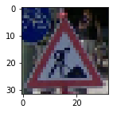

```
This image most likely belongs to 'Speed limit (30km/h)'
with a 100.00 percent confidence.
 Class ID is 1 vs 1
```

```
This image most likely belongs to 'Ahead only'
with a 100.00 percent confidence.
 Class ID is 35 vs 35
```

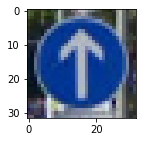

```
This image most likely belongs to 'Bicycles crossing'
with a 98.53 percent confidence.
 Class ID is 29 vs 29
```

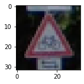

```
This image most likely belongs to 'Bicycles crossing'
with a 92.65 percent confidence.
 Class ID is 29 vs 29
```

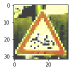

```
This image most likely belongs to 'Yield'
with a 100.00 percent confidence.
 Class ID is 13 vs 13
```

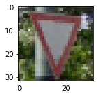

```
This image most likely belongs to 'Stop'
with a 100.00 percent confidence.
 Class ID is 14 vs 14
```

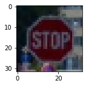

```
This image most likely belongs to 'Priority road'
with a 100.00 percent confidence.
 Class ID is 12 vs 12
```

[figure not shown]

```python
### Run the predictions here and use the model to output the prediction for each image.
### Make sure to pre-process the images with the same pre-processing pipeline used earlier.
### Feel free to use as many code cells as needed.
with tf.device('/device:GPU:1') :
    for x, y in new_ds:

        predictions = model.predict(x)

        score = tf.nn.softmax(predictions[0])

        print(
            "This image most likely belongs to '{}'\nwith a {:.2f} percent confidence.\n Class ID is {} vs {}"
            .format( sign_names_pd.iloc[ np.argmax(score)][1], 100 * np.max(score), np.argmax(score), y[0].numpy() )
        )

        #fig = plt.figure()
        #fig.add_subplot(221)

        im = x[0]
        im = tf.keras.preprocessing.image.img_to_array(im) * 255
        im = im.astype(np.uint8)
        plt.imshow( im )

        #fig.add_subplot(222)
        #draw_top5( score )

        plt.show()
```

### Analyze Performance

```python
### Calculate the accuracy for these 5 new images.
### For example, if the model predicted 1 out of 5 signs correctly, it's 20% accurate on these new images.
with tf.device('/device:GPU:1') :
    model.evaluate( new_ds )
```

[output not shown]

### Output Top 5 Softmax Probabilities For Each Image Found on the Web

For each of the new images, print out the model's softmax probabilities to show the **certainty** of the model's predictions (limit the output to the top 5 probabilities for each image). [`tf.nn.top_k`](https://www.tensorflow.org/versions/r0.12/api_docs/python/nn.html#top_k) could prove helpful here.

The example below demonstrates how tf.nn.top_k can be used to find the top k predictions for each image.

`tf.nn.top_k` will return the values and indices (class ids) of the top k predictions. So if k=3, for each sign, it'll return the 3 largest probabilities (out of a possible 43) and the correspoding class ids.

Take this numpy array as an example. The values in the array represent predictions. The array contains softmax probabilities for five candidate images with six possible classes. `tf.nn.top_k` is used to choose the three classes with the highest probability:

```
# (5, 6) array
a = np.array([[ 0.24879643,  0.07032244,  0.12641572,  0.34763842,  0.07893497,
         0.12789202],
       [ 0.28086119,  0.27569815,  0.08594638,  0.0178669 ,  0.18063401,
         0.15899337],
       [ 0.26076848,  0.23664738,  0.08020603,  0.07001922,  0.1134371 ,
         0.23892179],
       [ 0.11943333,  0.29198961,  0.02605103,  0.26234032,  0.1351348 ,
         0.16505091],
       [ 0.09561176,  0.34396535,  0.0643941 ,  0.16240774,  0.24206137,
         0.09155967]])
```

Running it through `sess.run(tf.nn.top_k(tf.constant(a), k=3))` produces:

```
TopKV2(values=array([[ 0.34763842,  0.24879643,  0.12789202],
       [ 0.28086119,  0.27569815,  0.18063401],
       [ 0.26076848,  0.23892179,  0.23664738],
       [ 0.29198961,  0.26234032,  0.16505091],
       [ 0.34396535,  0.24206137,  0.16240774]]), indices=array([[3, 0, 5],
       [0, 1, 4],
       [0, 5, 1],
       [1, 3, 5],
       [1, 4, 3]], dtype=int32))
```

Looking just at the first row we get `[ 0.34763842, 0.24879643, 0.12789202]`, you can confirm these are the 3 largest probabilities in `a`. You'll also notice `[3, 0, 5]` are the corresponding indices.

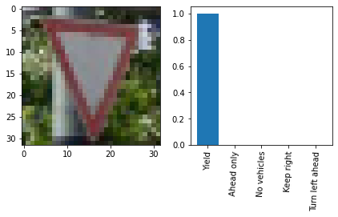

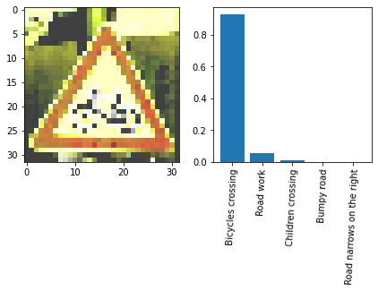

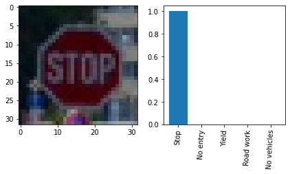

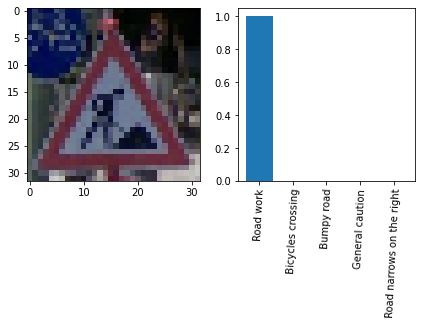

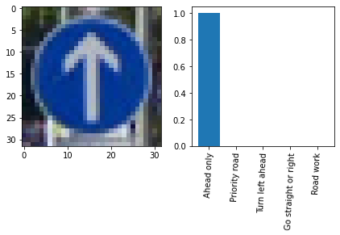

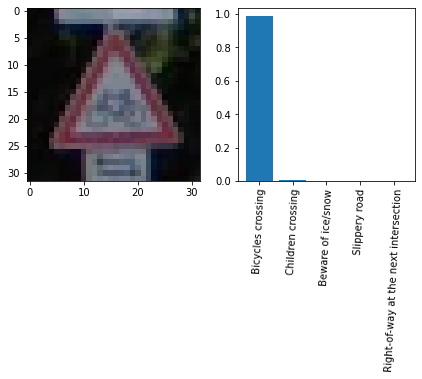

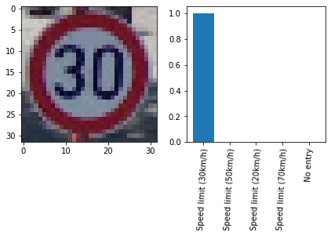

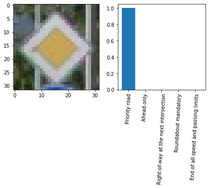

```python
### Print out the top five softmax probabilities for the predictions on the German traffic sign images found on the web.
### Feel free to use as many code cells as needed.
with tf.device('/device:GPU:1') :
    for x, y in new_ds:

        predictions = model.predict(x)

        score = tf.nn.softmax(predictions[0])

        fig = plt.figure(figsize=(7,7))
        fig.add_subplot(221)

        im = x[0]
        im = tf.keras.preprocessing.image.img_to_array(im) * 255
        im = im.astype(np.uint8)
        plt.imshow( im )

        fig.add_subplot(222)
        draw_top5( score )

        plt.show()
```

### Project Writeup

Once you have completed the code implementation, document your results in a project writeup using this [template](https://github.com/udacity/CarND-Traffic-Sign-Classifier-Project/blob/master/writeup_template.md) as a guide. The writeup can be in a markdown or pdf file.

## Step 4 (Optional): Visualize the Neural Network's State with Test Images

This Section is not required to complete but acts as an additional excersise for understaning the output of a neural network's weights. While neural networks can be a great learning device they are often referred to as a black box. We can understand what the weights of a neural network look like better by plotting their feature maps. After successfully training your neural network you can see what it's feature maps look like by plotting the output of the network's weight layers in response to a test stimuli image. From these plotted feature maps, it's possible to see what characteristics of an image the network finds interesting. For a sign, maybe the inner network feature maps react with high activation to the sign's boundary outline or to the contrast in the sign's painted symbol.

Provided for you below is the function code that allows you to get the visualization output of any tensorflow weight layer you want. The inputs to the function should be a stimuli image, one used during training or a new one you provided, and then the tensorflow variable name that represents the layer's state during the training process, for instance if you wanted to see what the LeNet lab's feature maps looked like for it's second convolutional layer you could enter conv2 as the tf_activation variable.

For an example of what feature map outputs look like, check out NVIDIA's results in their paper [End-to-End Deep Learning for Self-Driving Cars](https://devblogs.nvidia.com/parallelforall/deep-learning-self-driving-cars/) in the section Visualization of internal CNN State. NVIDIA was able to show that their network's inner weights had high activations to road boundary lines by comparing feature maps from an image with a clear path to one without. Try experimenting with a similar test to show that your trained network's weights are looking for interesting features, whether it's looking at differences in feature maps from images with or without a sign, or even what feature maps look like in a trained network vs a completely untrained one on the same sign image.

[figure not shown]

Your output should look something like this (above)

```python
plt.rcParams["figure.figsize"] = (3,3)

vis=[]

index = 0
for layer in model.layers:
    # check for convolutional layer

    index = index + 1
    if 'conv' not in layer.name:
        continue

    vis.append( [ index -1, layer.name, layer.output.shape] )

print( vis )
```

```
[[0, 'conv2d_92', TensorShape([None, 30, 30, 6])], [2, 'conv2d_93', TensorShape([None, 27, 27, 18])], [4, 'conv2d_94', TensorShape([None, 25, 25, 48])], [6, 'conv2d_95', TensorShape([None, 11, 11, 96])]]
```

```
input:
```

```
conv2d_92 (1, 30, 30, 6)
```

[figure not shown]

```
conv2d_93 (1, 27, 27, 18)
```

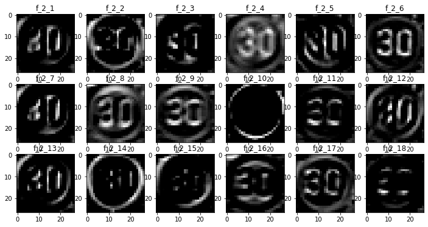

```
conv2d_94 (1, 25, 25, 48)
```

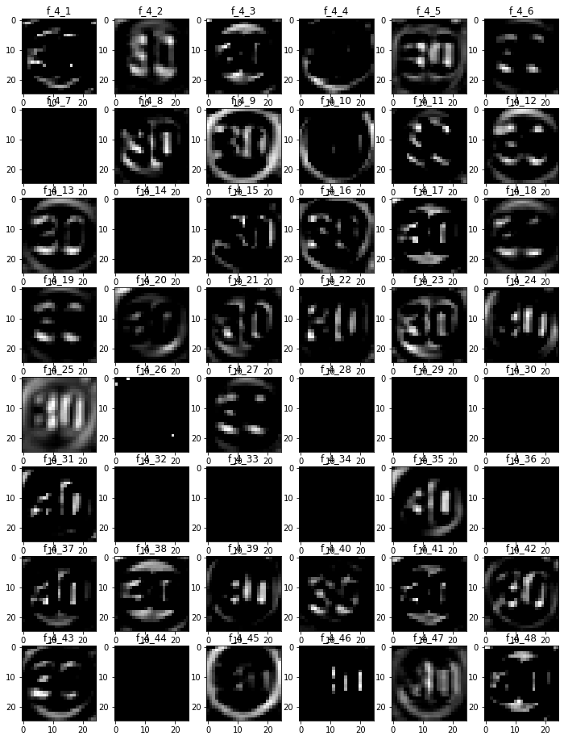

```
conv2d_95 (1, 11, 11, 96)
```

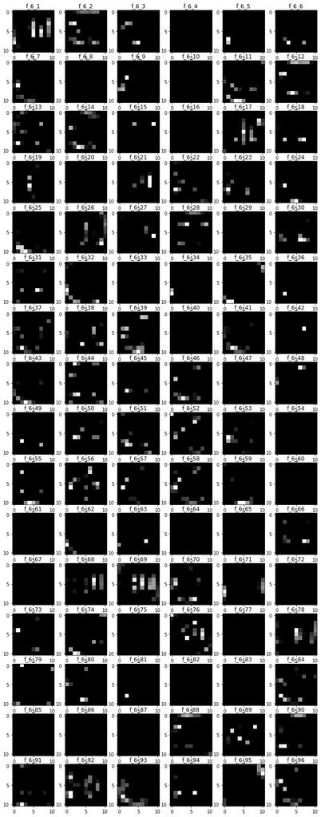

```python
plt.rcParams["figure.figsize"] = (2,2)

with tf.device('/device:GPU:1') :
    for x, y in new_ds:
        if y.numpy()[0]!=1:
            continue

        print( 'input:' )
        plt.imshow( (x[0]*255).numpy().astype(np.uint8) )
        plt.show()

        for v in vis :
            input_layer = model.input
            output_layer = model.layers[v[0]].output

            debug_model = tf.keras.models.Model( input_layer, output_layer )

            y = debug_model( x )
            print( v[1], y.shape )

            cols = 6
            rows = y.shape[3]//cols

            fig = plt.figure(figsize=(6*2,rows*2))

            ax=[None] * ( rows * cols )
            for i in range( rows * cols ) :
                ax[i] = fig.add_subplot(rows,cols,i+1)
                ax[i].set_title( 'f_'+str(v[0])+'_' + str( 1+i ) )
                ax[i].imshow( y[0,:,:,i], cmap='gray' )
            plt.show()
```

```python
### Visualize your network's feature maps here.
### Feel free to use as many code cells as needed.

# image_input: the test image being fed into the network to produce the feature maps
# tf_activation: should be a tf variable name used during your training procedure that represents the calculated state of a specific weight layer
# activation_min/max: can be used to view the activation contrast in more detail, by default matplot sets min and max to the actual min and max values of the output
# plt_num: used to plot out multiple different weight feature map sets on the same block, just extend the plt number for each new feature map entry

def outputFeatureMap(image_input, tf_activation, activation_min=-1, activation_max=-1 ,plt_num=1):
    # Here make sure to preprocess your image_input in a way your network expects
    # with size, normalization, ect if needed
    # image_input =
    # Note: x should be the same name as your network's tensorflow data placeholder variable
    # If you get an error tf_activation is not defined it may be having trouble accessing the variable from inside a function
    activation = tf_activation.eval(session=sess,feed_dict={x : image_input})
    featuremaps = activation.shape[3]
    plt.figure(plt_num, figsize=(15,15))
    for featuremap in range(featuremaps):
        plt.subplot(6,8, featuremap+1) # sets the number of feature maps to show on each row and column
        plt.title('FeatureMap ' + str(featuremap)) # displays the feature map number
        if activation_min != -1 & activation_max != -1:
            plt.imshow(activation[0,:,:, featuremap], interpolation="nearest", vmin =activation_min, vmax=activation_max, cmap="gray")
        elif activation_max != -1:
            plt.imshow(activation[0,:,:, featuremap], interpolation="nearest", vmax=activation_max, cmap="gray")
        elif activation_min !=-1:
            plt.imshow(activation[0,:,:, featuremap], interpolation="nearest", vmin=activation_min, cmap="gray")
        else:
            plt.imshow(activation[0,:,:, featuremap], interpolation="nearest", cmap="gray")
```